# IODS project

Ville Harjunen

## Introduction

Receiving a brief touch from a stranger has been shown increase receiver’s willingness to comply with sender’s requests. This widely known Midas Touch effect has also been found in computer mediated communication where the touch is approximated by electromechanical stimulation. However, recent findings suggest the effects of touch being particularly sensitive to other situational cues, such as accompanied emotional expressions. In the present study we investigate whether virtual agent’s facial expressions and touch influence person’s compliance in a repeated trials Ultimatum game and whether the agent’s facial expressions modify persuasiveness of the touch.

The Ultimatum game is an economic decision-making bargaining (UG; Guth, Schmittberger, & Schwarze, 1982) in which participants are assigned to one of two roles, proposer and receiver, and asked to divide money between themselves and their co-player. Proposer is asked to make either a fair or unfair offer to the receiver whose task is to decide whether to accept or reject the offer. If accepting, the money will be divided as proposed but if rejecting, neither player receives anything. Despite the fact that accepting evey offer would be the only rational strategy, people have been shown to reject unfair offers.

In the present study, we utilized an immersive virtual reality (VR) paradigm with haptic technology and motion tracking sensors to produce a strong illusion that participant is sharing his/her physical space with a virtual agent who, after showing a facial expression, reaches out and touched the participant. After these nonverbal cues, the player assigned to the role of proposer makes an offer of which the co-player (receiver) either accepted or rejected. In this study, both the receiver (i.e. participant receivers the offer) and proposer (i.e. participant makes the offer) trials were repeated multiple times with eight different virtual agents.

Due to the relative large and complex data set, the analyses of the final assignment will be restricted to the receiver trials in which the participant receives an unfair offer and his/her task is to decide whether to accep or reject it. Along the earlier findings of the Midas touch -effect, it was assumed (H1) that receiving a touch from a virtual agent increases participants’ likelihood to accept the subsecuent unfair offer. Given that smile has been shown to have similar persuasive effects, it was also assumed (H2) that agent’s emotional facial expressions affects the likelihood offers are accepted. Finally, because tactile communication is particularly sensitive to other situational cues, I assumed (H3) that agent’s happy expression enhances the persuasiveness of touch whereas angry expression reduces the Midas touch -effect.

## Short description of the study design

Repeated-measures design with three within subject factors (offer fairness, touch type, and facial expression) was used. Agents’ offers varied between very unfair (2e to the participant and 18e to the agent) to generous (18e to the participant and 2 to the agent) but this factor was later segmented to three categores (fair, little unfair, very unfair). Since almost all fair offers were accepted, I limited the analysis to the unfair offers. The touch type factor had three levels: visuo-tactile (participant can feel and see the touch), visual (participant sees the touch but does not feel anything), and no touch. Agents’ expressions consisted of happy, neutral and angry faces. Since the study included also EEG and autonomic nervous system measures (not included in the current analysis) which are extremely sensitive to noise, we had to repeat each of the touch_expression_offer condition many times. The resulting data is thus rather big and the amount of trials varies across participants after removing the trials with unsuccesful physiological measurements.

### Describing the data

Here is a link to the data wrangling script: https://github.com/villehar/IODS-final/blob/master/create_ultima.R

Before carrying out any inferential statistics, the data required some wrangling. In the raw data set, there were 21 variables and 38599 observations (trials). However, removing the proposer trials (i.e. trials in which the participant was the proposer) and a duplicated variable of pp’s gender resulted in a new data set “resp.data” with 20 variables and 28861 observations. The cleaning was continued removing pp’s who systematically accepted all offers and who had previous knowledge about the Ultimatum game or who had extensive amount of movement artifacts and other kind of noise in their physiological data (12 pps in total). The resulting resp.data3 has 16 variables (filter varibales were removed after the cleaning) and 10147 observations. The cleaned data set consisted of trials with not too long or short reaction times (50 - 3000 ms, there was a 100ms delay in the system so the actual reaction times varied across 150 and 3000 ms). Only the unfair offers were added as there no much variation in the fair offer trials (almost always accepted).

As can be seen, most of the variables are factorial. The pp indicates participant’s ID. The data includes variables of participant’s and agent’s gender (pp_sex, avsex), agents’ ethnicity (aveth) and pp’s average acceptance rate (accept.prop). Trial level variables of participant’s acceptances (accept), response time (RT), and offer-related cardiac orienting response (Cardiac_OR, mean inter-beat interval obtained 1-3 seconds after presenteing the agent’s offer) represent the outcome variables whereas agent’s touch type (touch), facial expression (emo), and the size of agent’s offer (offers) will be set as predictors. The continuous Cardiac_OR and RT variables will be used in the beginning when exploring the data but the final analyses will be limited to the binary outcome, “accept”.

```r
unfair.resp = read.csv(file = "Data/responder.csv", header = TRUE)
str(unfair.resp)
```

```
## 'data.frame':    10147 obs. of  16 variables:
##  $ pp          : int  101 101 101 101 101 101 101 101 101 101 ...
##  $ pp_sex      : Factor w/ 2 levels "female","male": 1 1 1 1 1 1 1 1 1 1 ...
##  $ trial       : int  1 3 12 13 16 17 39 40 42 44 ...
##  $ avsex       : Factor w/ 2 levels "F","M": 1 2 2 2 1 2 2 1 2 1 ...
##  $ aveth       : Factor w/ 4 levels "Af","Ca","Eu",..: 3 3 3 2 3 2 4 3 4 4 ...
##  $ emo         : Factor w/ 3 levels "Angry","Happy",..: 1 3 1 1 3 2 2 2 1 1 ...
##  $ touch       : Factor w/ 3 levels "none","tact",..: 1 2 2 1 3 3 3 2 2 1 ...
##  $ offers      : int  7 6 8 6 8 8 2 7 3 7 ...
##  $ Fairness    : Factor w/ 1 level "Unfair": 1 1 1 1 1 1 1 1 1 1 ...
##  $ accept      : logi  TRUE FALSE TRUE FALSE TRUE TRUE ...
##  $ Cardiac_OR  : num  -87.2 28.2 -20.5 102.3 -35.5 ...
##  $ RT          : int  2773 1973 799 1227 893 614 866 733 587 973 ...
##  $ Max_ibi_1_3s: num  -68.2 89 24.7 127.9 43.5 ...
##  $ accept.prop : num  0.887 0.887 0.887 0.887 0.887 ...
##  $ Block       : Factor w/ 2 levels "first half","last half": 1 1 1 1 1 1 1 1 1 1 ...
##  $ unfairness  : Factor w/ 3 levels "little","somewhat",..: 2 2 1 2 1 1 3 2 3 2 ...
```

## Data exploration

Due to long data format, it is harder to see how many participants there are and what is the gender distribution. One way is to use the pp colum to form a aggregated data frame with two variables (pp and pp_sex) and then crosstab the frequenies of cases by gender. The procedure revealed that there are 53 pps of which 32 are females and 21 are males (I always code females as ones).

```r
library(dplyr)
unfair <- unfair.resp
unfair$pp_sex <- as.numeric(unfair$pp_sex)
agg.unfair <- aggregate(unfair[1:2], by=list(unfair$pp), FUN=mean)

agg.unfair %>% select(pp, pp_sex) %>% group_by(pp_sex) %>% summarise(count = n())
```

```
## # A tibble: 2 × 2
##   pp_sex count
##    <dbl> <int>
## 1      1    32
## 2      2    21
```

```r
summary(unfair.resp)
```

```
##        pp           pp_sex         trial       avsex    aveth
##  Min.   :101.0   female:5903   Min.   :  1.0   F:5006   Af:2527
##  1st Qu.:119.0   male  :4244   1st Qu.:146.0   M:5141   Ca:2531
##  Median :135.0                 Median :290.0            Eu:2501
##  Mean   :134.7                 Mean   :293.8            Sa:2588
##  3rd Qu.:151.0                 3rd Qu.:440.0
##  Max.   :166.0                 Max.   :596.0
##       emo        touch          offers        Fairness       accept
##  Angry  :3369   none:3388   Min.   :2.000   Unfair:10147   Mode :logical
##  Happy  :3369   tact:3374   1st Qu.:5.000                  FALSE:5959
##  Neutral:3409   vis :3385   Median :6.000                  TRUE :4188
##                             Mean   :5.999                  NA's :0
##                             3rd Qu.:7.000
##                             Max.   :8.000
##    Cardiac_OR            RT          Max_ibi_1_3s      accept.prop
##  Min.   :-200.10   Min.   :  53.0   Min.   :-126.30   Min.   :0.3018
##  1st Qu.:  -2.68   1st Qu.: 346.0   1st Qu.:  23.87   1st Qu.:0.6014
##  Median :  29.24   Median : 466.0   Median :  57.73   Median :0.7005
##  Mean   :  32.39   Mean   : 613.6   Mean   :  63.32   Mean   :0.6757
##  3rd Qu.:  67.29   3rd Qu.: 733.0   3rd Qu.:  99.00   3rd Qu.:0.7793
##  Max.   : 212.06   Max.   :2987.0   Max.   : 246.94   Max.   :0.8874
##         Block         unfairness
##  first half:5233   little  :2521
##  last half :4914   somewhat:4027
##                    very    :3599
##
##
##
```

Some interesting interactions seemed to occur when inspecting the boxplots of acceptances and reaction times plotted separately for each level of unfairness. Reaction times were longer when rejecting very unfair offers and when accecting little unfair ones.

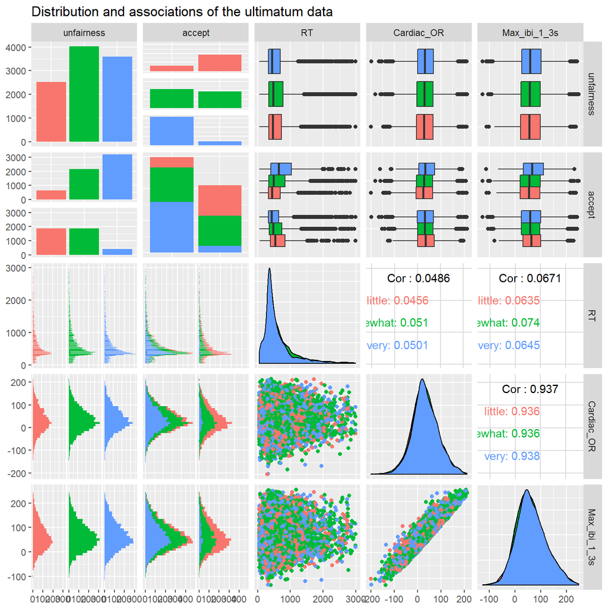

```r
library(tidyr)
library(GGally)
library(ggplot2)

unfair_small <- unfair.resp[,c(16,10,12,11,13)]
unfair_small$accept <- as.factor(unfair_small$accept)
explorative_plot <- ggpairs(unfair_small, title = "Distribution and associations of the ultimatum data", mapping = aes(color = unfairness), lower=list(combo=wrap("facethist",binwidth=10)))

explorative_plot
```

To take a brief look how agents’ touch and emotion affects response times and acceptances, I printed out a crosstable. It revealed that regardless of the touch type angry expression reduced participants’ likelihood to accept unfair offers. Visuo-tactile and visual touch both seemed to increase acceptances when compared to the no-touch condition. No clear interaction effec was observed between touch and emotion. The reaction times were faster in response to angry face. Touch did not seem to have effect on the reaction times.

```r
unfair.resp %>% select(unfairness, emo, touch, accept, RT) %>% group_by(touch, emo) %>% summarise(count = n(), RT_in_ms = mean(RT), proportion_of_acceptances = (mean(accept))*100)
```

```
## Source: local data frame [9 x 5]
## Groups: touch [?]
##
##    touch     emo count RT_in_ms proportion_of_acceptances
##   <fctr>  <fctr> <int>    <dbl>                     <dbl>
## 1   none   Angry  1129 591.8370                  32.94951
## 2   none   Happy  1127 612.5439                  44.27684
## 3   none Neutral  1132 631.6873                  42.13781
## 4   tact   Angry  1115 591.9336                  35.96413
## 5   tact   Happy  1118 628.9750                  45.70662
## 6   tact Neutral  1141 646.7791                  46.36284
## 7    vis   Angry  1125 577.3200                  32.26667
## 8    vis   Happy  1124 609.6566                  45.72954
## 9    vis Neutral  1136 630.7148                  45.95070
```

## Data analysis: Building a “naive” model

I started testing my hypothesis by calculating a logistic regression model which does not take into account the fact that the observations (trials) are clustered under participants and that there may thus be dependency between the observations. To take into account the correlation between these repeated trials, I used generalized estimating equations (GEE) when predicting the pp’s decisions (i.e. acceptances and rejections). However, to see how the glm based logistic regression differs from GEE, I first analyzed the data with normal logistic regression.

A simple glm model was built setting the accept as the outcome and unfairness, emo and touch as predictors. The results revealed a statistically significant effects of unfairness, emotion and touch. Angry expression and no-touch were set as comparison conditions to which other levels of emo and touch were contrasted.

```r
# defining the logistic regression model
naive <- glm(accept ~ unfairness + emo + touch, data = unfair.resp, family = "binomial")

# printing out model summary
summary(naive)
```

```
##
## Call:
## glm(formula = accept ~ unfairness + emo + touch, family = "binomial",
##     data = unfair.resp)
##
## Deviance Residuals:
##     Min       1Q   Median       3Q      Max
## -1.8009  -0.9178  -0.4184   0.9042   2.2901
##
## Coefficients:
##                    Estimate Std. Error z value Pr(>|z|)
## (Intercept)         0.59558    0.06428   9.265   <2e-16 ***
## unfairnesssomewhat -1.24236    0.05638 -22.037   <2e-16 ***
## unfairnessvery     -3.14240    0.06993 -44.938   <2e-16 ***
## emoHappy            0.65046    0.05812  11.192   <2e-16 ***
## emoNeutral          0.62894    0.05801  10.843   <2e-16 ***
## touchtact           0.15533    0.05739   2.706   0.0068 **
## touchvis            0.08773    0.05741   1.528   0.1265
## ---
## Signif. codes:  0 '***' 0.001 '**' 0.01 '*' 0.05 '.' 0.1 ' ' 1
##
## (Dispersion parameter for binomial family taken to be 1)
##
##     Null deviance: 13756  on 10146  degrees of freedom
## Residual deviance: 10873  on 10140  degrees of freedom
## AIC: 10887
##
## Number of Fisher Scoring iterations: 4
```

Estimated coefficients were then used to calculate odd ratios and their CIs. Investigating the odd ratios revealed that the likelihood of accepting unfair offers was 1.92 times more likely if receiving the offer from happy in contrary to angry agent and 1.88 times more likely if the offer was sent by neutral agent in contrats to angry agent. Being touched by the agent was also related to higher acceptances but here the effect was more modest (OR = 1.17 for visuo-tactile touch). Just seeing the agent’s touch did not lead to significant increase in acceptances.

```r
# transforming the coefficients to odd ratios
OR <- coef(naive) %>% exp

# calculating the confidential intervals for the odd rations
CI <- confint(naive) %>% exp

# printing out the OR results
cbind(OR, CI)
```

```
##                            OR      2.5 %     97.5 %
## (Intercept)        1.81409001 1.59990424 2.05848538
## unfairnesssomewhat 0.28870064 0.25837134 0.32227898
## unfairnessvery     0.04317907 0.03760887 0.04947111
## emoHappy           1.91642586 1.71044359 2.14810106
## emoNeutral         1.87562402 1.67438068 2.10189577
## touchtact          1.16804664 1.04381332 1.30718644
## touchvis           1.09169578 0.97552519 1.22176295
```

Since the midas touch effect was expected to depend on toucher’s emotional expression, I then added an interaction term to the model. No significant interaction was found between emotion and touch.

```r
# defining the logistic regression model with emo*touch interaction
naive2 <- glm(accept ~ unfairness + emo + touch + emo:touch, data = unfair.resp, family = "binomial")

# printing out model summary
summary(naive2)
```

```
##
## Call:
## glm(formula = accept ~ unfairness + emo + touch + emo:touch,
##     family = "binomial", data = unfair.resp)
##
## Deviance Residuals:
##     Min       1Q   Median       3Q      Max
## -1.7972  -0.9166  -0.4315   0.9281   2.2923
##
## Coefficients:
##                      Estimate Std. Error z value Pr(>|z|)
## (Intercept)           0.61935    0.08034   7.709 1.27e-14 ***
## unfairnesssomewhat   -1.24386    0.05642 -22.045  < 2e-16 ***
## unfairnessvery       -3.14634    0.06999 -44.952  < 2e-16 ***
## emoHappy              0.69003    0.10019   6.887 5.70e-12 ***
## emoNeutral            0.52491    0.09981   5.259 1.45e-07 ***
## touchtact             0.19980    0.10107   1.977   0.0481 *
## touchvis             -0.02539    0.10180  -0.249   0.8031
## emoHappy:touchtact   -0.18168    0.14136  -1.285   0.1987
## emoNeutral:touchtact  0.04920    0.14086   0.349   0.7269
## emoHappy:touchvis     0.06516    0.14160   0.460   0.6454
## emoNeutral:touchvis   0.26646    0.14172   1.880   0.0601 .
## ---
## Signif. codes:  0 '***' 0.001 '**' 0.01 '*' 0.05 '.' 0.1 ' ' 1
##
## (Dispersion parameter for binomial family taken to be 1)
##
##     Null deviance: 13756  on 10146  degrees of freedom
## Residual deviance: 10866  on 10136  degrees of freedom
## AIC: 10888
##
## Number of Fisher Scoring iterations: 4
```

A chi-square test was then calculated to see whether the model fit was better in the more complex “naive2” model than in the original “naive” model. There was no difference in the goodness of fit which suggests that I should run the GEE without the interaction term since it just makes the model more complex without adding any predictive power.

```r
anova(naive, naive2, test ="Chisq")
```

```
## Analysis of Deviance Table
##
## Model 1: accept ~ unfairness + emo + touch
## Model 2: accept ~ unfairness + emo + touch + emo:touch
##   Resid. Df Resid. Dev Df Deviance Pr(>Chi)
## 1     10140      10873
## 2     10136      10866  4   6.9954   0.1361
```

The problem with this analysis is that the model “thinks” that the data comes from 10147 persons (or independent sources) and this assumption increases the risk of Type 1 error, particulrly if the within subject autocorrelation is strong (ref.). Next I will run the same analysis with GEE that takes into account that there are 53 participants, each with around 200 trials.

## Data analysis: Taking dependency into account with GEE

Genelized estimating equation (GEE) is commonly used in epidemiological studies as it allows researchers to predict categorical and binary outcomes (for example presence/absence of certain disease) while handling dependency occuring within the data. In the current study, we can assume that each person has a slightly diffrent way of reacting to virtual agents’ expressions, touches and offers. There may thus be some similarities between the observations obtained from one participant which should be taken into account when making the predictions.

Below you see a geeglm model equivalent to the “naive” model. The model structure resembles the glm fuction but it has more basic options that have to be defined. The term “id” stands for the vector identiying the clusters (participants). Similarly to glm, “family”" indicates the error distribution and link function to be used in the model. Finally, “corstr” is used to specify the correlation structure used for the clustered data.

If the correlation structure is set to “independence” the GEE gives results identical to those obtained iwth the glm. To see how taking into account the dependency affects the results, I run the gee model but with two different correlation structures: ar1 and exhangeable.

Repeated measures anova uses the so called compound symmetry structure which is referred here as exchangeable. Another structure used in repeated measres data is the autoregressive ar1 structure. These structures would thus be good candidates for my data.

On the other hand, in my study the observations within each cluster have been collected along time, which makes it unlikely that trials separated by, let say, 100 trials will correlate as as stronly as trials that are adjacent. This detail makes the exchangeable structure less optimal as is assumes that observations within a cluster are equally correlated with each other. We are also not assuming a temporal trend withing the cluster of repetitions (unless habituation) and it is thus unlikely that autoregressive structre (ar1) would be the most appropriate. Geepack includes 5 different correlation structures: independence, exchangeable, ar1, unstructured and userdefined. There seems to be no clear option as the unstructured is too heavy for such a big amount of observations and because the independent structure does not add anything to the earlier glm solution.

Despite the concerns, I decided to try both exchangeable and ar1 and see what happens.

```r
library(geepack)

mf <- formula(accept ~ unfairness + emo + touch)
gee_exh <- geeglm(mf, data=unfair.resp, id = pp, family="binomial",corstr="exchangeable")
summary(gee_exh)
```

```
##
## Call:
## geeglm(formula = mf, family = "binomial", data = unfair.resp,
##     id = pp, corstr = "exchangeable")
##
##  Coefficients:
##                    Estimate  Std.err    Wald Pr(>|W|)
## (Intercept)         0.55993  0.25747   4.729  0.02965 *
## unfairnesssomewhat -1.25410  0.14846  71.357  < 2e-16 ***
## unfairnessvery     -3.19349  0.26147 149.169  < 2e-16 ***
## emoHappy            0.66600  0.16870  15.586 7.88e-05 ***
## emoNeutral          0.64025  0.13959  21.036 4.51e-06 ***
## touchtact           0.16443  0.06281   6.853  0.00885 **
## touchvis            0.08688  0.06848   1.610  0.20452
## ---
## Signif. codes:  0 '***' 0.001 '**' 0.01 '*' 0.05 '.' 0.1 ' ' 1
##
## Estimated Scale Parameters:
##             Estimate Std.err
## (Intercept)    1.014   0.184
##
## Correlation: Structure = exchangeable  Link = identity
##
## Estimated Correlation Parameters:
##       Estimate Std.err
## alpha   0.2189 0.05664
## Number of clusters:   53   Maximum cluster size: 222
```

There were no big changes in the results when running the model with ar1 structure. Since there may have been some habituation effect as a result of the rather long experimental session, I continued working with the ar1 structure and calculated the odd ratios based on the coefficients of the ar1 model.

```r
mf <- formula(accept ~ unfairness + emo + touch)
gee_ar1 <- geeglm(mf, data=unfair.resp, id = pp, family="binomial",corstr="ar1")
summary(gee_ar1)
```

```
##
## Call:
## geeglm(formula = mf, family = "binomial", data = unfair.resp,
##     id = pp, corstr = "ar1")
##
##  Coefficients:
##                    Estimate Std.err   Wald Pr(>|W|)
## (Intercept)          0.6262  0.2558   5.99  0.01437 *
## unfairnesssomewhat  -1.2977  0.1574  67.95  2.2e-16 ***
## unfairnessvery      -3.2071  0.2576 154.98  < 2e-16 ***
## emoHappy             0.6388  0.1742  13.45  0.00024 ***
## emoNeutral           0.6058  0.1453  17.39  3.0e-05 ***
## touchtact            0.1620  0.0621   6.81  0.00907 **
## touchvis             0.1183  0.0716   2.73  0.09827 .
## ---
## Signif. codes:  0 '***' 0.001 '**' 0.01 '*' 0.05 '.' 0.1 ' ' 1
##
## Estimated Scale Parameters:
##             Estimate Std.err
## (Intercept)     1.01   0.132
##
## Correlation: Structure = ar1  Link = identity
##
## Estimated Correlation Parameters:
##       Estimate Std.err
## alpha    0.727  0.0452
## Number of clusters:   53   Maximum cluster size: 222
```

Inspecting the odd ratios revealed that the likelihood of accepting unfair offers was 1.89 times higher when the agent smiled and 1.83 times higher if neutral face was shown than when agent looked angry. Also the visuo-tactile touch increased the likelihood. People were 1.17 times more likely to accept unfair offers if being touched by the agent before receiving the offer. The same was not true when no tactile sensation was accompanied by the touch. The effect of unfairness of acceptances was again much greater than the effects of emotion and touch.

```r
# calculating the odd ratios
OR <- coef(gee_ar1) %>% exp
# calculating the confidential intervals for the odd rations
cc <- coef(summary(gee_ar1))
citab <- with(as.data.frame(cc),
     cbind(lwr=Estimate-1.96*Std.err,
           upr=Estimate+1.96*Std.err))
CI <- citab %>% exp

# printing out the OR results
cbind(OR, CI)
```

```
##                        OR    lwr    upr
## (Intercept)        1.8705 1.1329 3.0882
## unfairnesssomewhat 0.2732 0.2006 0.3719
## unfairnessvery     0.0405 0.0244 0.0671
## emoHappy           1.8943 1.3464 2.6651
## emoNeutral         1.8327 1.3786 2.4364
## touchtact          1.1758 1.0411 1.3279
## touchvis           1.1256 0.9783 1.2951
```

## Conclusion

The present study investigated whether receiving a smile or touch from a virtual agent increase compliance in economic social-decision making game and whether the toucher’s facial expression modifies the effect of touch on decision-making. The current analysis was limited to unfair offers sent by the agent and received by human subjects. The results support earlier demonstrated Midas-touch effect as they show that receiving a touch from the proposer increases the likelihood of accepting unfair offers. The effect of touch was, however, more modest than the effects of actual offer size and facial expression of the proposer. No interaction effect was found between the expression and touch, which in turn speaks agains my third hypothesis that the midas-touch effect would depend on toucher’s expression.

The data was first analysed using glm approach that did not take into account dependency of the observations btained with the repeated measures desing. Consecuently, there was an elevanted risk of Type 1 error. To handle the dependency in the observations the analyses were carried out with generalized estimating equations that take into account the hierarchial structure of the data and allow various different correlation structures for the estimation process. Despite marginal changes in the model estimates, the gee produced results similar to those obtained with logistic regression. In future I will continue searching for method that helps me to decide which correlation structure should be used if there is no clear apriori reason to use a certain structure.